# Group 5 Semantic Segmentation - Report

## Group member: pab734 wxw870 zxw780 txd844 cxb980 gxk636

## 1. Introduction

In recent years, there has been a huge amount of convolutional neural network structures come out for semantic segmentation tasks. The most famous of these is AlexNet, proposed by Alex Krizhevsky in 2012 on the ILSVRC competition, which opened the door to the application of deep convolutional neural networks on GPU and beat all traditional algorithms.

This assignment comes from the 2017 Automated Cardiac Diagnosis Challenge (ACDC). We will be designing a convolutional neural network to segment the CMR images into four distinct regions(the background region (black), the left ventricle (LV) region (white), the myocardium (Myo) region (white gray) and the right ventricle (RV) region (dark gray).) as accurately and reliably as possible, to reduce the time-consuming, labour-intensive and poor quality of manual segmentation.

The dataset provided to us was split in advance into training, validation and test. For the training set, there are 100 CMR images and 100 respective ground truth mask images. We will use these to train our model. For the validation set, there are 20 CMR images and 20 mask images, we will use the set to tune the hyperparameters of our networks. For the test set, we will use it for kaggle submission to prove that our model is valid.

We want our convolutional neural network to be able to appropriately segment the test data to the four regions to a high accuracy. We want our network to avoid underfitting and overfitting, instead producing a reasonable mask of any given image. In order for us to achieve this we will be focusing on finding the optimum network architecture and loss function for image segmentation. Furthermore, by using optimisers and augmenting the dataset we aim to increase the accuracy and reliability of the segmentation.

## 2. Implementation

### 2.1 Preprocessing - Data Augmentation

We augmented the data by using numpy to flip our data set (fliplr() and flipud()) and rotated the data anti-clockwise in steps of 90 degrees (rot90()) three times to increase the size of the dataset from 100 images to 600.This increase in variety in our data will decrease the risk of the network remembering the training data andhelp prevent a large difference in segmentation performance from training to validation in the network.

### 2.2 Segmentation Model - FCN

The idea of FCN is based on CNN. It replaced the fully connected layer of CNN by fully convolutional layer and it can classify images at the pixel level. Therefore, it solved the semantic segmentation of image segmentation. Finally, the loss of SoftMax classification is calculated pixel by pixel, which is equivalent to one training label for each pixel. Overall, FCN replaces the fully connected layer at the end of CNN with the convolutional layer, and the output an image which is already labeled.

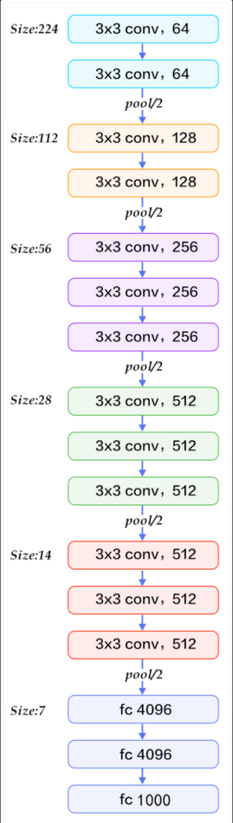

VGG-16 Structure

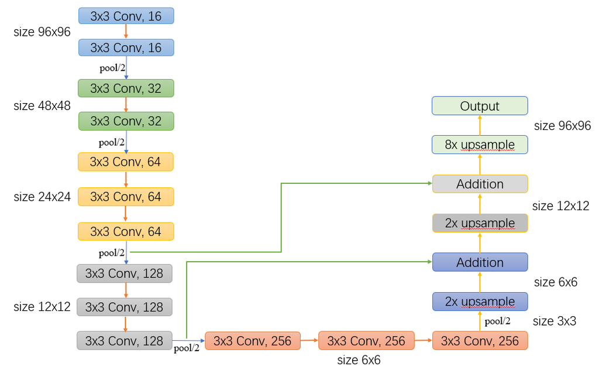

VGG16-FCN Structure

Then the upsample part aims to make the convolved image return to the input size. The easiest way to implement this is to use upsampling at a factor of 32. However, as we can see on figure2 the predicted mask, it is generally similar with origin mask, the details are very poor. In addition, the accuracy of validation in this case is only around 70%.

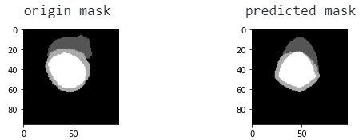

Unsampling as factor of 32

Therefore, we use upsampling at a factor of 2 first, apply this to the output of convolutional layer, and add with the output of fourth convolutional part, we get “x1”. Using “x1” and add with the output of third convolutional part, we get “x2”. Finally, using “x2” with upsampling at a factor of 8, we get the predicted output. Now, the predicted mask as shown on figure 3, most of the details are fine, and we can reach the maximum validation accuracy about 88%.

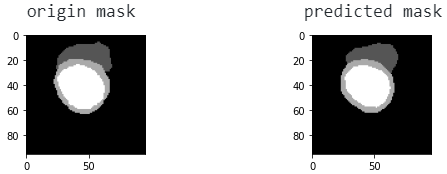

Upsampling as factor of 2,2,8

In summary, there are 5 convolutional part and 3 upsample part in our VGG16-FCN network. The output shape of each convolutional part after maxpool are 48*48*16, 24*24*32, 12*12*64, 6*6*128, 3*3*256. Total parameters in this network are 2,578,292 and total storage is about 25.76MB.

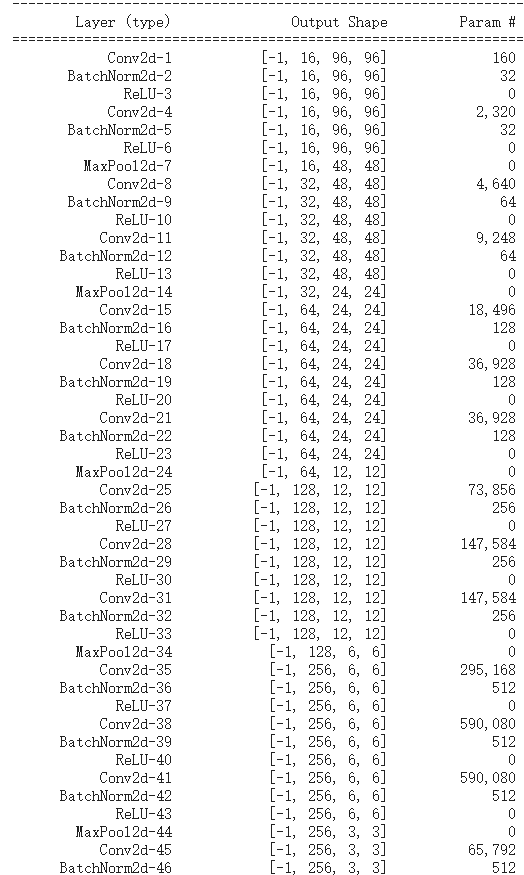

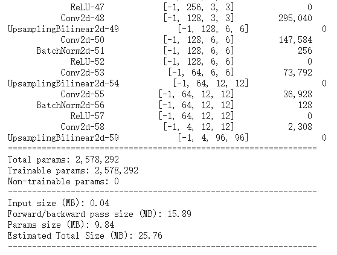

VGG16-FCN Structure Summary

References

- [1] [VERY DEEP CONVOLUTIONAL NETWORKS FOR LARGE-SCALE IMAGE RECOGNITION (2015)](https://arxiv.org/pdf/1409.1556.pdf)
- [2] [Fully Convolutional Networks for Semantic Segmentation (2015)](https://www.cv-foundation.org/openaccess/content_cvpr_2015/papers/Long_Fully_Convolutional_Networks_2015_CVPR_paper.pdf)
- [3] [Understanding and implementing a fully convolutional network (FCN) (2020)](https://www.cv-foundation.org/openaccess/content_cvpr_2015/papers/Long_Fully_Convolutional_Networks_2015_CVPR_paper.pdf)

### 2.3 Segmentation Model - DeepLab v3 plus

Besides the network we implement with FCN and VGG-16, we also explore many other network architectures. The Deeplab series is the most interesting to us, and we have chosen the latest one to perform semantic segmentation on our task. The state-of-art network Deeplab v3 plus was proposed in 2018 by Google and has been open-sourced on TensorFlow, which combines the advantages of various networks of recent years.

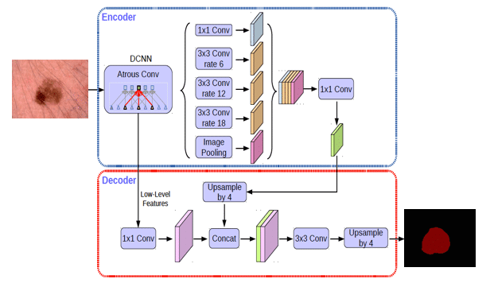

Deeplab v3 plus network

As seen in the image above, the network uses the Encoder-Decoder framework which was used before such as network U-Net. The encoder part gradually reduces spatial dimensionality, while the decoder gradually restores spatial dimensionality by using bilinear upsampling with low-level features to detail the information.

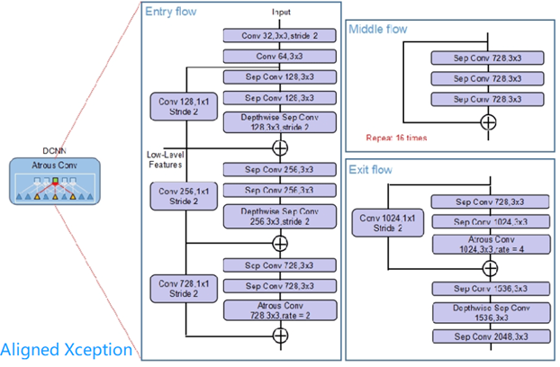

For the encoder part, the DCNN module of v3 plus using the Aligned Xception.

In the entry flow, the image goes through three blocks. What they have in common is that they are all roughly downsampled with a 1x1 filter by a factor of two and increased channels, then it added with the feature map after 3 rounds of 3x3 filter depthwise separable convolution. In the last layer of the last entry flow block, a atrous convolution with rate 2 is used at the end to preserve field of view. The final feature map output size of entry flow is 6*6.

In the last exit flow, the first block has the same functionality of the blocks in the entry flow, the last layer of it does the last atrous convolution with rate 4 and then using 3 depthwise convolutional layers increase only the channels of feature map, without changing the size of it.

Then ASPP module after the DCNN was used to extract of feature maps of different sizes for final concatenation.

For the decoder part, the decoder first reduces channels of low-level feature map produced during the second block of the entry flow of the encoder with a 1x1 filter convolutional layer, then concatenates the output of the encoder which was after bilinear 4x upsampling, then use two 3x3 filters convolutional layer and one 1x1 filter convolutional layer before the final bilinear 4x upsampling, and then upsampling 4x to get the final mask with size and channels of [4,4,96,96].

After implementing the network structures, we try to train the model with our data set. We didn’t make much changes to the network initially, and we were able to train the model with our own data augmentation training set to achieve 84-92% accuracy, but the validation set only achieved 62-70% accuracy. This is a sign of overfitting.

So, we did the same thing we did for VGG-16, by changing the channels of each layers inside of the network, in addtion, we add dropout inside to avoid overfitting. We keep the output stride to be 16 rather than 32, which means the output feature map of encoder will be the size of 6*6 (height and width reduced by 16 times compared to the original image size 96*96).

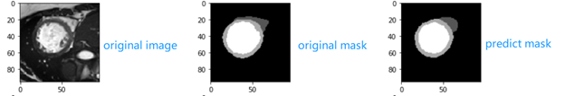

In summary, the DeepLab series has been one of the most important semantic segmentation networks to date.It started with an atrous convolution and gradually added more features from other networks, such as SPP and Decoder, to make it even stronger.

References

- [1] [DeepLabv1 (2014)](https://arxiv.org/abs/1412.7062v3)
- [2] [DeepLabv2 (2016)](https://arxiv.org/abs/1606.00915)
- [3] [DeepLabv3 (2017)](https://arxiv.org/abs/1706.05587)
- [4] [DeepLabv3+ (2018)](https://arxiv.org/abs/1802.02611)
- [5] [Review: DeepLabv3 — Atrous Convolution (Semantic Segmentation)](https://towardsdatascience.com/review-deeplabv3-atrous-convolution-semantic-segmentation-6d818bfd1d74)
- [6] [Rapid and robust two-dimensional phase unwrapping via deep learning](https://www.researchgate.net/publication/334781960_Rapid_and_robust_two-dimensional_phase_unwrapping_via_deep_learning)
- [7] [Semantic Segmentation丨DeepLab series summary "v1, v2, v3, v3+"](https://www.cnblogs.com/vincent1997/p/10889430.html)

### 2.4 Loss functions

However, individual loss functions have weaknesses; these weaknesses can be bridged by considering several loss functions in conjunction. We implemented such a function, “CrossDice”. This is a basic combination of Soft dice loss and Cross entropy loss. In this function the individual loss values are calculated, before they are multiplied to produce an overall loss value. I expect this function to perform better than the standard soft dice implementation, as it will accommodate for the weaknesses in bias and overfitting by introducing Cross Entropy loss into the function.

- [1] [Loss function overview](https://www.jeremyjordan.me/semantic-segmentation/)
- [2] [Soft Dice bias(2019)](https://arxiv.org/abs/1911.02278)

## 3. Experiment

### 3.1 Network Structure Exploration

#### 3.1.1 Exploration of FCN

As mentioned above, we use the VGG16 part as our convolutional layer and we make some adapt to ensure it works for the semantic segmentation problem and magnetic resonance dataset. The maxmimum output channel of convolutional part is 256. First we run the code and record the accuracy with 30 epochs. For training accuracy we get 0.9406743479764327, and for validation accuracy we get 0.8855803757465012. To explore the effect of maximum output channel, we change it back to 512 output channel, after 30 epochs, training accuracy is about 0.9374731797315499 and validation accuracy is about 0.8494254030432498. When the maximum channels comes to 1024, training accuracy is 0.842717234335964 and validation accuracy is 0.6667127922305118. It can be seen it's not a good idea to add maximum channels, the accuracy decreases and parameters increasing exponentially, so in this case training time becomes much more longer.

Meanwhile, we also made an exploration on the decrease of channel number. We change the maximum output channel to 64, the training accuracy becomes 0.9069645811242893 and validation accuracy is 0.8243246999504535.

Overall, we abtain that the training time is effected by channel number. And accuracy is not the more the better or the less the better. It is necessary to explore an suitable parameters for each paticular problem. Therefore, the best maximum channels for this dataset is 256, with epochs 30.

#### 3.1.2 Exploration of Deeplab v3 plus

Significantly reducing the number of operations in a neural network is still one of the goals of network structure optimization due to the hardware constraints of the device.

Before improvement, the DCNN part of Deeplab v3 plus was using original backbone as suggested in the original paper which was ResNet-101 using the complete convolution like the v3 version, google later released the new suggestion on tensorflow by using depthwise separable convolution in the new backbone --> Aligned Xception(a fine tune version of the Xception network). As you can see it above, we use the new suggestion to solve the former network being very computationally intensive and demanding of hardware.

We do some math to understand the benefits of doing so. The core idea is to decompose a complete convolutional operation into two steps, Depthwise Convolution and Pointwise Convolution.

Assuming that the input layer is a 3-channel colour image of size 64x64, and that it passes through a convolution layer with 4 filters, the final output is 4 feature maps, each of the filter size is 3 × 3. The number of parameters used in a regular convolution operation is 4 × 3 × 3 × 3 = 108.

If a Depthwise separable convolution is used, the first convolution is performed in a two-dimensional plane, and the number of filters is the same as the depth of the previous layer. The number of parameters in depthwise convolution part is 3 × 3 × 3 = 27. This does not make effective use of the information from different maps at the same spatial location. So the Pointwise Convolution operation (1×1×Depth) will combine the maps from the previous step in a weighted manner in the depth direction to generate a new Feature map. The number of parameters in pointwise convolution part is 1 × 1 × 3 × 4 = 12.

Total parameters: 27 + 12 = 39

The number of parameters for depthwise separable convolution is about 1/3 of the number for the complete convolution.

### 3.2 Loss Function

The first consideration regarding loss functions is which one to use. To ascertain if there was a frontrunner, we first tested each loss function on a basic model with only a subset of the data over 50 epochs. This experiment did not show one function as a clear frontrunner, but rather showed one as clearly less appropriate than the others. A table of results can be seen below.

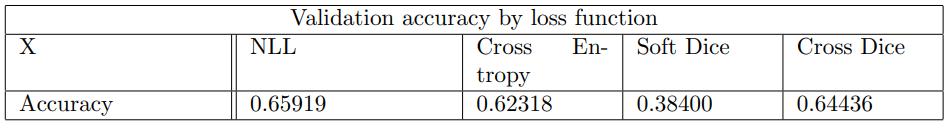

As can be seen in the above table, Soft Dice loss performs considerably worse than the other approaches, so a purely Soft Dice loss function was deemed to be inappropriate for this task. Although some approaches do slightly better than others, it would be unwise to draw any such conclusions between these approaches as this was only tested on a small subset of the data.

Despite performing well on the more simple models, Cross Dice and NLL losses struggled with more comprehensive models or larger datasets/more training epochs. In validation, these approaches could only achieve an average accuracy of around 0.85, whereas Cross Entropy loss achieved around 0.89 in validation. I believe this is largely an issue of overfitting and a lack of stability in the approaches, as the training accuracy was still sound despite the instability in loss which ultimately yielded poor results when run on the unseen validation data.

There are few parameters to be varied in loss functions. In Cross Entropy loss, the only parameter to be varied is applying weights to the different classes to lessen the impact of an unbalanced dataset. The default weight of a class is 1, such that a weight of 0.5 will halve the impact of the given class. In this task there are 4 classes representing different areas of the mask, and intuitively the background is much more significant than the rest of the image. To test this hypothesis, we first ran 4 test configurations where one weight was set to 0.5 and the rest left as 1. The model was only trained for 20 epochs on a subset of the data for efficiency. The results of this test are shown in the table below

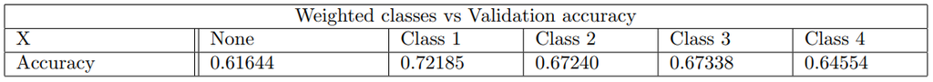

As can be seen above, a lesser weighting for Class 1 produces far better results then the other tests performed, whilst weighting the other classes does not exhibit a significant improvement on accuracy. Because of this, we chose to use Cross Entropy loss with a reduced weighting for Class 1. It follows intuitively that reducing the weights of several classes will reduce the impact of the other reductions, so it is important to limit the number of weight reductions that take place. Therefore, as there are only 4 classes in this example we chose to only reduce the weight of the most optimal class, which is class 1.

### 3.3 Optimisation Algorithm

To compare the optimisation algorithms, we would train the network with each algorithm and compare their performance using validation loss and accuracy. For this experiment the default parameters for each algorithm is used unless specified, and the network is trained for 30 and 100 epochs. the following graphs show how each algorithm performed on the training set.

\

> Loss plot of different optimizers

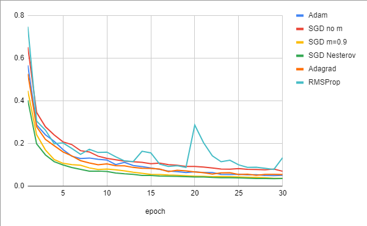

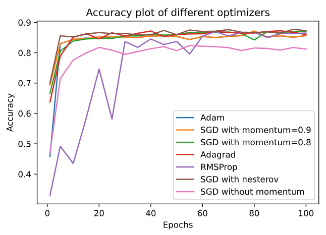

From these two graph, we can't see which one is the best, as most of them have a high performance and the difference between the optimizers is not large. However, we can easily see that SGD without momentum is the wrost. Therefore, we choose the most popular one as our optimizer - Adam, and with learning rate equals to 0.01.

Flowing table shows that the best accuracy these optimizers can reach when epochs is 100.

| Algorithm | Accuracy |
| --- | --- |
| RMSProp | 0.8670796400880978 |
| Adam | 0.871593 |
| SGD no m | 0.8237062171503006 |
| SGD m=0.9 | 0.855722375 |
| SGD m=0.8 | 0.8701014 |
| SGD Nesterov | 0.8770761070861137 |
| Adagrad | 0.8726112344768182 |

Now we see that SGD Nesterov has the best performance. However, as mentioned above, the difference between them is very small.

References

- [1] [Gentle Introduction to the Adam Optimization Algorithm for Deep Learning (2017)](https://machinelearningmastery.com/adam-optimization-algorithm-for-deep-learning/#:~:text=Adam%20is%20a%20replacement%20optimization,sparse%20gradients%20on%20noisy%20problems)

## 4. Conclusion

In the deeplab v3 plus network, we found that there are three key enhancements that are important. Due to the large amount of network parameters computed, the use of depth separable convolution becomes critical, using the new backbone to do a perfect illustration of this. Secondly, ASPP was retained to increase speed while increasing the field of view with enhanced perception of different sizes of the same object. The Encoder-Decoder framework incrementally recovers features from the feature map rather than directly up-sampling or accessing the fully-connected layer, which also improves accuracy and efficiency. Lastly, adjusting the number of channels between the layers of the network and adding dropout to prevent overfitting are necessary to achieve high accuracy as usual.

We tried several loss functions, but ultimately the relatively simple Cross Entropy loss was the most effective. We believe this is down to overfitting caused by the more complex Soft Dice loss and the combined “Cross Dice” function. From the related literature we know that Cross Entropy is a robust metric which is often the most effective loss function for image segmentation problems, so it was expected that this function would perform well in this problem. The weighting for each class was also similar to what we hypothesised, where the background would cause the dataset to be somewhat unbalanced so should be given a lesser weight compared to the rest of the classes. This increased performance on the validation set compared to an unweighted set.

For the optimizer, each algorithm doesn’t have a large difference between them, the performance is quite well. We choose currently the most popular one – Adam as our optimizer. It is an alternative stochastic gradient descent optimization algorithm for training deep learning models, and it combines the best features of the AdaGrad and RMSProp algorithms to provide an optimization algorithm that can deal with sparse gradients on noise problems. In addition, Adam’s memory requirement is low and suitable for a large and high dimension dataset, especially image problem.

Overall, after extensive tuning and experimentation, our FCN network achieved a final test set accuracy of 88.4%, while the more complex Deeplab achieved a maximum test set accuracy of 85.2% in this task, despite many structural improvements.

# Group 5 Semantic Segmentation - Code

## 1. Load, show, and save images with OpenCV

This is to ensure OpenCV works fine in loading, showing and saving images and path is correct.

***Code is copied form tutorial***

```python
from matplotlib import pyplot as plt
def show_image_mask(img, mask, cmap='gray'): # visualisation
    fig = plt.figure(figsize=(5,5))
    plt.subplot(1, 2, 1)
    plt.imshow(img, cmap=cmap)
    plt.axis('off')
    plt.subplot(1, 2, 2)
    plt.imshow(mask, cmap=cmap)
    plt.axis('off')
```

```python
import os
import cv2 #import OpenCV

data_dir = './data/train'
image = cv2.imread(os.path.join(data_dir,'image','cmr1.png'), cv2.IMREAD_UNCHANGED)
mask = cv2.imread(os.path.join(data_dir,'mask','cmr1_mask.png'), cv2.IMREAD_UNCHANGED)
show_image_mask(image, mask, cmap='gray')
plt.pause(1)
cv2.imwrite(os.path.join('./','cmr1.png'), mask*85)
```

[figure not shown]

```
True
```

## 2. Preprocessing - Data Augmentation

The original training set is 100 images, which is not enough and may cause the overfitting. Therefore, we applied Data Augmentation to generate more training data.

We applied:

- Flip from left to right
- Flip from up to down
- Rotate 90°
- Rotate 180°
- Rotate 270°

Now we have 600 images and masks for training

```python
import matplotlib.pyplot as plt
import numpy as np
import cv2
import os

input_dir = './data/train'
output_dir = './new_data/train'
files = ['image', 'mask']

for file_name in files:
    input_path = os.path.join(input_dir, file_name)
    output_path = os.path.join(output_dir, file_name)
    for img_name in os.listdir(input_path):
        image = cv2.imread(os.path.join(input_path, img_name), cv2.IMREAD_UNCHANGED)

        #Flip from left to right
        flippedlr_img = np.fliplr(image)
        cv2.imwrite(os.path.join(output_path, img_name), image)
        cv2.imwrite((output_path + '/flipped_' + img_name), flippedlr_img)

        #Flip from up to down
        flippedud_img = np.flipud(image)
        cv2.imwrite(os.path.join(output_path, img_name), image)
        cv2.imwrite((output_path + '/flippedud_' + img_name), flippedud_img)

        #Rotate 90°
        rotated90_img = np.rot90(image)
        cv2.imwrite(os.path.join(output_path, img_name), image)
        cv2.imwrite((output_path + '/rotated90_' + img_name), rotated90_img)

        #Rotate 180°
        rotated180_img = np.rot90(rotated90_img)
        cv2.imwrite(os.path.join(output_path, img_name), image)
        cv2.imwrite((output_path + '/rotated180_' + img_name), rotated180_img)

        #Rotate 270°
        rotated270_img = np.rot90(rotated180_img)
        cv2.imwrite(os.path.join(output_path, img_name), image)
        cv2.imwrite((output_path + '/rotated270_' + img_name), rotated270_img)
```

```python
#Show the image of genereated data augmentation examples

mask1 = cv2.imread(os.path.join(output_dir, 'mask', 'cmr34_mask.png'), cv2.IMREAD_UNCHANGED)
mask2 = cv2.imread(os.path.join(output_dir, 'mask', 'flipped_cmr34_mask.png'), cv2.IMREAD_UNCHANGED)
mask3 = cv2.imread(os.path.join(output_dir, 'mask', 'flippedud_cmr34_mask.png'), cv2.IMREAD_UNCHANGED)
mask4 = cv2.imread(os.path.join(output_dir, 'mask', 'rotated90_cmr34_mask.png'), cv2.IMREAD_UNCHANGED)
mask5 = cv2.imread(os.path.join(output_dir, 'mask', 'rotated180_cmr34_mask.png'), cv2.IMREAD_UNCHANGED)
mask6 = cv2.imread(os.path.join(output_dir, 'mask', 'rotated270_cmr34_mask.png'), cv2.IMREAD_UNCHANGED)

plt.imshow(mask1, cmap='gray')
plt.show()
plt.imshow(mask2, cmap='gray')
plt.show()
plt.imshow(mask3, cmap='gray')
plt.show()
plt.imshow(mask4, cmap='gray')
plt.show()
plt.imshow(mask5, cmap='gray')
plt.show()
plt.imshow(mask6, cmap='gray')
plt.show()
```

[figure not shown]

## 2. Define a segmentation model with pytorch

### 2.1 Check whether the GPU is accessible

If the GPU is accessible, it will be used for training. Otherwise, using CPU

```python
import torch
device = torch.device("cuda:0" if torch.cuda.is_available() else "cpu")
print(device)
```

```
cuda:0
```

### 2.2 Define a Dataloader

***Code is copied form tutorial***

```python
import torch
import torch.utils.data as data
import cv2
import os
from glob import glob

class TrainDataset(data.Dataset):
    def __init__(self, root=''):
        super(TrainDataset, self).__init__()
        self.img_files = glob(os.path.join(root,'image','*.png'))
        self.mask_files = []
        for img_path in self.img_files:
            basename = os.path.basename(img_path)
            self.mask_files.append(os.path.join(root,'mask',basename[:-4]+'_mask.png'))


    def __getitem__(self, index):
            img_path = self.img_files[index]
            mask_path = self.mask_files[index]
            data = cv2.imread(img_path, cv2.IMREAD_UNCHANGED)
            label = cv2.imread(mask_path, cv2.IMREAD_UNCHANGED)
            return torch.from_numpy(data).float(), torch.from_numpy(label).float()

    def __len__(self):
        return len(self.img_files)

class TestDataset(data.Dataset):
    def __init__(self, root=''):
        super(TestDataset, self).__init__()
        self.img_files = glob(os.path.join(root,'image','*.png'))

    def __getitem__(self, index):
            img_path = self.img_files[index]
            data = cv2.imread(img_path, cv2.IMREAD_UNCHANGED)
            return torch.from_numpy(data).float()

    def __len__(self):
        return len(self.img_files)
```

### 2.2.1 Define a Segmentation Model - FCN

```python
import torch
import torch.nn as nn
import torch.nn.functional as F


class CNNSEG(nn.Module): # Define your model
    def __init__(self):
        super(CNNSEG, self).__init__()
        # fill in the constructor for your model here

        self.relu = nn.ReLU()

        #Define first Convolutional layer
        self.conv1_1 = nn.Conv2d(in_channels=1, out_channels=16, kernel_size=(3,3), padding=1, stride=1)
        self.conv1_2 = nn.Conv2d(in_channels=16, out_channels=16, kernel_size=(3,3), padding=1, stride=1)
        self.batchnorm1 = nn.BatchNorm2d(16)

        #Define second Convolutional layer
        self.conv2_1 = nn.Conv2d(in_channels=16, out_channels=32, kernel_size=(3,3), padding=1, stride=1)
        self.conv2_2 = nn.Conv2d(in_channels=32,out_channels=32, kernel_size=(3,3), padding=1, stride=1)
        self.batchnorm2 = nn.BatchNorm2d(32)

        #Define third Convolutional layer
        self.conv3_1 = nn.Conv2d(in_channels=32, out_channels=64, kernel_size=(3,3), padding=1, stride=1)
        self.conv3_2 = nn.Conv2d(in_channels=64, out_channels=64, kernel_size=(3,3), padding=1, stride=1)
        self.conv3_3 = nn.Conv2d(in_channels=64, out_channels=64, kernel_size=(3,3), padding=1, stride=1)
        self.batchnorm3 = nn.BatchNorm2d(64)

        #Define fourth Convolutional layer
        self.conv4_1 = nn.Conv2d(in_channels=64, out_channels=128, kernel_size=(3,3), padding=1, stride=1)
        self.conv4_2 = nn.Conv2d(in_channels=128, out_channels=128, kernel_size=(3,3), padding=1, stride=1)
        self.conv4_3 = nn.Conv2d(in_channels=128, out_channels=128, kernel_size=(3,3), padding=1, stride=1)
        self.batchnorm4 = nn.BatchNorm2d(128)

        #Define fifth Convolutional layer
        self.conv5_1 = nn.Conv2d(in_channels=128, out_channels=256, kernel_size=(3,3), padding=1, stride=1)
        self.conv5_2 = nn.Conv2d(in_channels=256, out_channels=256, kernel_size=(3,3), padding=1, stride=1)
        self.conv5_3 = nn.Conv2d(in_channels=256, out_channels=256, kernel_size=(3,3), padding=1, stride=1)
        self.batchnorm5 = nn.BatchNorm2d(256)

        #Define the transition layer. Only change the channel
        self.trans1 = nn.Conv2d(in_channels=256, out_channels=128, kernel_size=(3,3), padding=1, stride=1)
        self.trans2 = nn.Conv2d(in_channels=128, out_channels=64, kernel_size=(3,3), padding=1, stride=1)
        self.trans3 = nn.Conv2d(in_channels=64, out_channels=4, kernel_size=(3,3), padding=1, stride=1)
        self.trans4 = nn.Conv2d(in_channels=128, out_channels=128, kernel_size=(3,3), padding=1, stride=1)
        self.trans5 = nn.Conv2d(in_channels=64, out_channels=64, kernel_size=(3,3), padding=1, stride=1)

        #Define the maxpool layer, reduce the size to one half
        self.maxpool = nn.MaxPool2d(kernel_size=(2,2), stride=2)

        #Define the upsample layer
        self.upsample_2x = nn.UpsamplingBilinear2d(scale_factor=2)
        self.upsample_8x = nn.UpsamplingBilinear2d(scale_factor=8)







    def VGG16part(self, x):

        # VGG Block1, input(4,1,96,96) -> output(4,16,48,48)
        x1 = self.relu(self.batchnorm1(self.conv1_1(x))) #(4,1,96,96) -> (4,16,96,96)
        x1 = self.relu(self.batchnorm1(self.conv1_2(x1))) #(4,16,96,96)
        x1 = self.maxpool(x1) #(4,16,48,48)

        # VGG Block2, input(4,16,48,48) -> output(4,32,24,24)
        x2 = self.relu(self.batchnorm2(self.conv2_1(x1))) #(4,32,48,48)
        x2 = self.relu(self.batchnorm2(self.conv2_2(x2))) #(4,32,48,48)
        x2 = self.maxpool(x2) #(4,32,24,24)

        # VGG Block3, input(4,32,24,24) -> output(4,64,12,12)
        x3 = self.relu(self.batchnorm3(self.conv3_1(x2))) #(4,64,24,24)
        x3 = self.relu(self.batchnorm3(self.conv3_2(x3))) #(4,64,24,24)
        x3 = self.relu(self.batchnorm3(self.conv3_3(x3))) #(4,64,24,24)
        x3 = self.maxpool(x3) #(4,64,12,12)

        # VGG Block4, input(4,64,12,12) -> output(4,128,6,6)
        x4 = self.relu(self.batchnorm4(self.conv4_1(x3))) #(4,128,12,12)
        x4 = self.relu(self.batchnorm4(self.conv4_2(x4))) #(4,128,12,12)
        x4 = self.relu(self.batchnorm4(self.conv4_3(x4))) #(4,128,12,12)
        x4 = self.maxpool(x4) #(4,128,6,6)

        # VGG Block5, input(4,128,6,6) -> output(4,256,3,3)
        x5 = self.relu(self.batchnorm5(self.conv5_1(x4))) #(4,256,6,6)
        x5 = self.relu(self.batchnorm5(self.conv5_2(x5))) #(4,256,6,6)
        x5 = self.relu(self.batchnorm5(self.conv5_3(x5))) #(4,256,6,6)
        x5 = self.maxpool(x5) #(4,256,3,3)

        return x1,x2,x3,x4,x5

    def forward(self, x):
        # fill in the forward function for your model here

        # get the output of VGG16 part
        x1,x2,x3,x4,x5 = self.VGG16part(x)

        # Upsampleing layer1, at a factor of 2  input(4,256,3,3)->(4,128,6,6)+(4,128,6,6)->output(4,128,6,6)
        x6 = self.trans1(x5) #(4,128,3,3)
        x6 = self.upsample_2x(x6) #(4,128,6,6)
        x7 = x6 + x4 #(4,128,6,6)
        x7 = self.relu(self.batchnorm4(self.trans4(x7)))

        # Upsampleing layers2, at a factor of 2  input(4,128,6,6)->(4,64,12,12)+(4,45,12,12)->output(4,64,12,12)
        x8 = self.trans2(x7) #(4,64,6,6)
        x8 = self.upsample_2x(x8) #(4,64,12,12)
        x9 = x3 + x8 #(4,64,12,12)
        x9 = self.relu(self.batchnorm3(self.trans5(x9)))

        # Upsampleing layers2, at a factor of 8  input(4,64,12,12)->(4,4,96,96)+(4,4,96,96)->output(4,4,96,96)
        out = self.trans3(x9) #(4,4,12,12)
        out = self.upsample_8x(out) #(4,4,96,96)

        return out

model = CNNSEG().to(device) # We can now create a model using your defined segmentation model
```

### 2.2.2 Define a Segmentation Model - DeepLab V3+

```python
import torch
import torch.nn as nn
import torch.nn.functional as F



class SeparableConv2d(nn.Module):
    def __init__(self,in_channels,out_channels,kernel_size=1,stride=1,padding=0,dilation=1,bias=False):
        super(SeparableConv2d,self).__init__()

        self.conv1 = nn.Conv2d(in_channels,in_channels,kernel_size,stride,padding,dilation,groups=in_channels,bias=bias)
        self.pointwise = nn.Conv2d(in_channels,out_channels,kernel_size=1,stride=1,padding=0,dilation=1,groups=1,bias=bias)

    def forward(self,x):
        x = self.conv1(x)
        x = self.pointwise(x)
        return x
# Change this Xception implementation to Aligned Xception https://github.com/hoya012/pytorch-Xception/blob/master/Xception_pytorch.ipynb
class Xception(nn.Module):
    def __init__(self, input_channel):
        super(Xception, self).__init__()

        # Entry Flow
        self.entry_flow_1 = nn.Sequential(
            nn.Conv2d(input_channel, 16, kernel_size=3, stride=2, padding=1, bias=False), # 48*48 output stride = 2
            nn.BatchNorm2d(16),
            nn.ReLU(True),

            nn.Conv2d(16, 32, kernel_size=3, stride=1, padding=1),
            nn.BatchNorm2d(32),
            nn.ReLU(True)
        )

        self.entry_flow_2 = nn.Sequential(
            SeparableConv2d(32, 64, 3, 1, padding=1),
            nn.BatchNorm2d(64),
            nn.ReLU(True),

            SeparableConv2d(64, 64, 3, 1, padding=1),
            nn.BatchNorm2d(64),
            nn.ReLU(True),

            # Improve for deeplab v3+
            # Depthwise Convolution
            SeparableConv2d(64, 64, 3, 2, padding=1),# 24*24 output stride = 4
            nn.BatchNorm2d(64),
            nn.ReLU(True),

        )

        self.entry_flow_2_residual = nn.Conv2d(32, 64, kernel_size=1, stride=2, padding=0) # 24*24 output stride = 4

        self.entry_flow_3 = nn.Sequential(

            SeparableConv2d(64, 128, 3, 1, padding=1),
            nn.BatchNorm2d(128),
            nn.ReLU(True),

            SeparableConv2d(128, 128, 3, 1, padding=1),
            nn.BatchNorm2d(128),
            nn.ReLU(True),

            # Improve for deeplab v3+
            # Depthwise Convolution
            SeparableConv2d(128, 128, 3, 2, padding=1),# 12*12 output stride = 8
            nn.BatchNorm2d(128),
            nn.ReLU(True),

        )

        self.entry_flow_3_residual = nn.Conv2d(64, 128, kernel_size=1, stride=2, padding=0) # 12*12 output stride = 8

        self.entry_flow_4 = nn.Sequential(

            SeparableConv2d(128, 256, 3, 1, padding=1),
            nn.BatchNorm2d(256),
            nn.ReLU(True),

            SeparableConv2d(256, 256, 3, 1, padding=1),
            nn.BatchNorm2d(256),
            nn.ReLU(True),

            # Improve for deeplab v3+
            # Atrous Convolution
            nn.Conv2d(in_channels=256,out_channels=256,kernel_size=3,stride=2,padding=2,dilation=2), # 6*6 output stride = 16 with atrous
            nn.BatchNorm2d(256),
            nn.ReLU(True),

        )

        self.entry_flow_4_residual = nn.Conv2d(128, 256, kernel_size=1, stride=2, padding=0) # 6*6 output stride = 16

        # Middle Flow
        self.middle_flow = nn.Sequential(

            SeparableConv2d(256, 256, 3, 1, padding=1), # keep size 6*6
            nn.BatchNorm2d(256),
            nn.ReLU(True),

            SeparableConv2d(256, 256, 3, 1, padding=1),
            nn.BatchNorm2d(256),
            nn.ReLU(True),

            SeparableConv2d(256, 256, 3, 1, padding=1),
            nn.BatchNorm2d(256),
            nn.ReLU(True),
        )

        # Exit Flow
        self.exit_flow_1 = nn.Sequential(
            SeparableConv2d(256, 256, 3, 1, padding=1),
            nn.BatchNorm2d(256),
            nn.ReLU(True),

            SeparableConv2d(256, 512, 3, 1, padding=1),
            nn.BatchNorm2d(512),
            nn.ReLU(True),

            # Atrous Convolution
            nn.Conv2d(in_channels=512,out_channels=512,kernel_size=3,stride=1,padding=4,dilation=4), # 6*6 output stride = 16 with atrous
            nn.BatchNorm2d(512),
            nn.ReLU(True),

        )
        self.exit_flow_1_residual = nn.Conv2d(256, 512, kernel_size=1, stride=1, padding=0) # 6*6 output stride = 16

        self.exit_flow_2 = nn.Sequential(
            SeparableConv2d(512, 768, 3, 1, padding=1),
            nn.BatchNorm2d(768),
            nn.ReLU(True),

            # Improve for deeplab v3+
            # Depthwise Convolution
            SeparableConv2d(768, 768, 3, 1, padding=1),
            nn.BatchNorm2d(768),
            nn.ReLU(True),

            SeparableConv2d(768, 1024, 3, 1, padding=1),
            nn.BatchNorm2d(1024),
            nn.ReLU(True)
        )


    def forward(self, x):
        entry_out1 = self.entry_flow_1(x)
        entry_out2 = self.entry_flow_2(entry_out1) + self.entry_flow_2_residual(entry_out1)
        entry_out3 = self.entry_flow_3(entry_out2) + self.entry_flow_3_residual(entry_out2)
        entry_out = self.entry_flow_4(entry_out3) + self.entry_flow_4_residual(entry_out3)


        middle_out = self.middle_flow(entry_out) + entry_out

        for i in range(7):
            middle_out = self.middle_flow(middle_out) + middle_out

        exit_out1 = self.exit_flow_1(middle_out) + self.exit_flow_1_residual(middle_out)
        exit_out2 = self.exit_flow_2(exit_out1)

        output = exit_out2

        return output,entry_out2

class ASPP(nn.Module):
    def __init__(self, inplanes, planes, rate):
        super(ASPP, self).__init__()
        self.atrous_convolution = nn.Conv2d(inplanes, planes, kernel_size=3,
                        stride=1, padding=rate, dilation=rate)
        self.batch_norm = nn.BatchNorm2d(planes)
        self.relu = nn.ReLU(True)

    def forward(self, x):
        x = self.atrous_convolution(x)
        x = self.batch_norm(x)
        x = self.relu(x)

        return x

class CNNSEG(nn.Module): # Define your model
    def __init__(self):
        super(CNNSEG, self).__init__()
        # Step 1 feature extractor
        self.feature_extractor = Xception(input_channel=1)
        self.output_stride = 16

        # Step 2 ASPP
        #ASPP
        rates = [6, 12, 18]
        self.aspp1 = nn.Conv2d(1024, 256, kernel_size=1)
        self.aspp1_bn = nn.BatchNorm2d(256)

        self.aspp2 = ASPP(1024, 256, rate=rates[0])
        self.aspp3 = ASPP(1024, 256, rate=rates[1])
        self.aspp4 = ASPP(1024, 256, rate=rates[2])

        self.global_avg_pool = nn.Sequential(nn.AdaptiveAvgPool2d((1, 1)),
                        nn.Conv2d(1024, 256, 1, stride=1),
                        nn.BatchNorm2d(256),
                        nn.ReLU(True)
                        )
        self.relu = nn.ReLU(True)
        self.dropout_0_5 = nn.Dropout2d(0.5)

        self.conv1 = nn.Conv2d(1280, 256, 1)
        self.bn1 = nn.BatchNorm2d(256)

        # Decoder Part
        #channel reduction to 32.
        self.conv2 = nn.Conv2d(64, 32, 1)
        self.bn2 = nn.BatchNorm2d(32)


        self.last_conv = nn.Sequential(nn.Conv2d(288, 256, kernel_size=3, stride=1, padding=1),
                        nn.BatchNorm2d(256),
                        nn.ReLU(True),
                        nn.Conv2d(256, 256, kernel_size=3, stride=1, padding=1),
                        nn.BatchNorm2d(256),
                        nn.ReLU(True),
                        nn.Dropout2d(0.1),
                        nn.Conv2d(256, 4, kernel_size=1, stride=1))

    def forward(self, x):

        # Encoder Part
        x,low_level_features = self.feature_extractor(x)

        x1 = self.aspp1(x)
        x1 = self.aspp1_bn(x1)

        x2 = self.aspp2(x)
        x3 = self.aspp3(x)
        x4 = self.aspp4(x)
        x5 = self.global_avg_pool(x)

        x5 = F.interpolate(x5, size=x4.size()[2:], mode='bilinear', align_corners=True)



        # Decoder Part
        x = torch.cat((x1, x2, x3, x4, x5), dim=1)
        x = self.conv1(x)
        x = self.bn1(x)
        x = self.dropout_0_5(x)

        x = F.interpolate(x, scale_factor= self.output_stride//4, mode='bilinear', align_corners=True)

        low_level_features = self.conv2(low_level_features)
        low_level_features = self.bn2(low_level_features)

        x = torch.cat((x, low_level_features), dim=1)
        x = self.last_conv(x)

        x = F.interpolate(x, scale_factor= self.output_stride//(self.output_stride//4), mode='bilinear', align_corners=True)

        return x

model = CNNSEG().to(device) # We can now create a model using your defined segmentation model
```

### 2.3 Test the output shape of the model

Check whether the model output shape is as expected

```python
def test(model):
    output_test = torch.rand(4,1,96,96).to(device)
    output_test = model.forward(output_test)
    print(output_test.shape)

test(model)
```

```
torch.Size([4, 4, 96, 96])
```

## 3. Train the model

### 3.1 Define a Loss Function and Optimizer

```python
# from mxtorch.trainer import ScheduledOptim
def sum_tensor(inp, axes, keepdim=False):
    # copy from: https://github.com/MIC-DKFZ/nnUNet/blob/master/nnunet/utilities/tensor_utilities.py
    axes = np.unique(axes).astype(int)
    for ax in sorted(axes, reverse=True):
        inp = inp.sum(int(ax))
    return inp

def get_results(net_output, gt, axes, mask=None):
    # Shape of output and target
    shape_x = net_output.shape
    shape_y = gt.shape

    with torch.no_grad():
        if len(shape_x) != len(shape_y):
            gt = gt.view((shape_y[0], 1, *shape_y[1:]))

        # Check if one hot encoding, if not encode
        if all([i == j for i, j in zip(net_output.shape, gt.shape)]):
            y_onehot = gt
        else:
            gt = gt.long()
            y_onehot = torch.zeros(shape_x)
            if net_output.device.type == "cuda":
                y_onehot = y_onehot.cuda(net_output.device.index)
            y_onehot.scatter_(1, gt, 1)

    tp = net_output * y_onehot
    fp = net_output * (1 - y_onehot)
    fn = (1 - net_output) * y_onehot

    # Sum tensor values
    tp = sum_tensor(tp, axes)
    fp = sum_tensor(fp, axes)
    fn = sum_tensor(fn, axes)

    return tp, fp, fn

class SoftDiceLoss(nn.Module):
    def __init__(self,smooth=0.1):
        super(SoftDiceLoss, self).__init__()
        self.smooth = smooth

    def forward(self, x, y, loss_mask=None):
        shp_x = x.shape
        axes = list(range(2, len(shp_x)))

        true_p, false_p, false_n = get_results(x, y, axes)
        dc = (2 * true_p + self.smooth) / (2 * true_p + false_p + false_n + self.smooth)
        dc = dc.mean()

        return 1-dc

class CrossDice(nn.Module):
    def __init__(self, dice=None, cross = None, weight=None, size_average=True):
        super(CrossDice, self).__init__()
        weights = [0.5, 1.0, 1.0, 1.0]
        class_weights = torch.FloatTensor(weights).to(device)
        self.dice = SoftDiceLoss()
        self.cross = nn.CrossEntropyLoss(weight = class_weights)

    def forward(self, inputs, targets):
        cross_loss = self.cross.forward(inputs, targets)
        dice_loss = self.dice.forward(inputs, targets)

        comb_loss = cross_loss*dice_loss

        return comb_loss

weights = [0.5, 1.0, 1.0, 1.0]
class_weights = torch.FloatTensor(weights).to(device)
Loss = nn.CrossEntropyLoss(weight = class_weights)
# Loss = nn.NLLLoss2d() #"write your loss function here"
optimizer = torch.optim.Adam(params=model.parameters(), lr=0.01)  #"write your optimizer here"
```

### 3.2 Define a Evaluation function to measure the performance - Dice Score

***Code is copied form tutorial***

```python
def categorical_dice(mask1, mask2, label_class=1):
    """
    Dice score of a specified class between two volumes of label masks.
    (classes are encoded but by label class number not one-hot )
    Note: stacks of 2D slices are considered volumes.

    Args:
        mask1: N label masks, numpy array shaped (H, W, N)
        mask2: N label masks, numpy array shaped (H, W, N)
        label_class: the class over which to calculate dice scores

    Returns:
        volume_dice
    """
    mask1_pos = (mask1 == label_class).astype(np.float32)
    mask2_pos = (mask2 == label_class).astype(np.float32)
    dice = 2 * np.sum(mask1_pos * mask2_pos) / (np.sum(mask1_pos) + np.sum(mask2_pos))
    return dice
```

### 3.2 Training

#### This part is to train the FCN network

```python
from torch.utils.data import DataLoader
import numpy as np
import time

def training(train_epochs=50):
    data_path = './new_data/train'
    if(torch.cuda.is_available):
        num_workers = 0
    else:
        num_workers = 4
    batch_size = 4
    train_set = TrainDataset(data_path)
    training_data_loader = DataLoader(dataset=train_set, num_workers=num_workers, batch_size=batch_size, shuffle=True)

    model.train()

    epochs = train_epochs

    for epoch in range(epochs):
        # Fetch images and labels.
        train_loss = 0
        train_acc = 0
        start_time = time.time()
        i=0
        for iteration, sample in enumerate(training_data_loader):
            img, mask = sample

            # show_image_mask(img[0,...].squeeze(), mask[0,...].squeeze()) #visualise all data in training set
            # plt.pause(1)

            # Write your FORWARD below
            # Note: Input image to your model and ouput the predicted mask and Your predicted mask should have 4 channels
            # img = img.unsqueeze(1).to(device)
            img = img.view(4,1,96,96).to(device)
            # mask = mask.unsqueeze(1).to(device)
            # mask = mask.view(4,1,96,96).to(device)
            mask = mask.to(device)
            mask = mask.type(torch.long)

            # model.zero_grad()
            optimizer.zero_grad()
            out = model.forward(img)
            out = F.log_softmax(out)

            # Then write your BACKWARD & OPTIMIZE below
            # Note: Compute Loss and Optimize
            loss = Loss(out, mask)
            loss.backward()
            optimizer.step()
            train_loss += loss.data.item()

            pred = out.max(1)[1].squeeze().cpu().data.numpy()

            score = 0
            for i in range(4):
                score += categorical_dice(np.array(pred), np.array(mask.cpu()), i)
            # score = categorical_dice(np.array(pred), np.array(mask.cpu()), 0)
            # score += categorical_dice(np.array(pred), np.array(mask.cpu()), 1)
            # score += categorical_dice(np.array(pred), np.array(mask.cpu()), 2)
            # score += categorical_dice(np.array(pred), np.array(mask.cpu()), 3)

            train_acc += score/4

        print("epoch: ", epoch, "| loss: ", train_loss/len(training_data_loader), "| training time: ", time.time()-start_time, "| accuracy: ", train_acc/len(training_data_loader))

training()
```

```
epoch:  0 | loss:  0.5809913462400437 | training time:  2.948157548904419 | accuracy:  0.4251926405430448
epoch:  1 | loss:  0.49018646995226545 | training time:  2.9053516387939453 | accuracy:  0.5050250244302021
epoch:  2 | loss:  0.402495043973128 | training time:  2.9035074710845947 | accuracy:  0.6247136724141183
epoch:  3 | loss:  0.3008748576045036 | training time:  2.891695261001587 | accuracy:  0.7314207346686348
epoch:  4 | loss:  0.2348385487993558 | training time:  2.9042837619781494 | accuracy:  0.7882034278609735
epoch:  5 | loss:  0.2069884898265203 | training time:  3.038207769393921 | accuracy:  0.8181373332780417
epoch:  6 | loss:  0.17149866749842962 | training time:  3.0017168521881104 | accuracy:  0.8455830145498922
epoch:  7 | loss:  0.14236929828921954 | training time:  2.997830867767334 | accuracy:  0.8690128162354076
epoch:  8 | loss:  0.1405327611664931 | training time:  2.992931842803955 | accuracy:  0.8698418805837298
epoch:  9 | loss:  0.12925332779685655 | training time:  2.91202712059021 | accuracy:  0.8782627897681721
epoch:  10 | loss:  0.10960315624872843 | training time:  2.9116547107696533 | accuracy:  0.8954897524496198
epoch:  11 | loss:  0.10250475466251373 | training time:  2.9367520809173584 | accuracy:  0.9011078740870431
epoch:  12 | loss:  0.09469499533375104 | training time:  2.9796106815338135 | accuracy:  0.9087151580934706
epoch:  13 | loss:  0.0863139671087265 | training time:  2.88789701461792 | accuracy:  0.9152441459065326
epoch:  14 | loss:  0.09194617547094822 | training time:  2.8895766735076904 | accuracy:  0.9118016275294012
epoch:  15 | loss:  0.08921742091576258 | training time:  2.903683662414551 | accuracy:  0.9143601398987681
epoch:  16 | loss:  0.07624266157547632 | training time:  2.885929822921753 | accuracy:  0.9243514340986652
epoch:  17 | loss:  0.07513607469697793 | training time:  2.8920485973358154 | accuracy:  0.9255970480574571
epoch:  18 | loss:  0.07478280576566855 | training time:  2.894094467163086 | accuracy:  0.926425067507948
epoch:  19 | loss:  0.07372114467124144 | training time:  2.892092704772949 | accuracy:  0.926653783145707
epoch:  20 | loss:  0.06757143857578436 | training time:  2.8928487300872803 | accuracy:  0.932879272376644
epoch:  21 | loss:  0.06511380210518837 | training time:  2.9065282344818115 | accuracy:  0.9350866597460741
epoch:  22 | loss:  0.06638326197862625 | training time:  2.8973071575164795 | accuracy:  0.9337640884709193
epoch:  23 | loss:  0.06496245235204696 | training time:  2.8980159759521484 | accuracy:  0.9347263332157928
epoch:  24 | loss:  0.07476321573058764 | training time:  2.8951478004455566 | accuracy:  0.9268565720943119
epoch:  25 | loss:  0.06686937627693017 | training time:  2.8952057361602783 | accuracy:  0.9323620453019363
epoch:  26 | loss:  0.059660211876034736 | training time:  2.8984053134918213 | accuracy:  0.9402331641530405
epoch:  27 | loss:  0.056167954901854195 | training time:  2.891409397125244 | accuracy:  0.9432176433532427
epoch:  28 | loss:  0.05794501254955928 | training time:  2.896782875061035 | accuracy:  0.9415774875655202
epoch:  29 | loss:  0.055508225187659264 | training time:  2.8923962116241455 | accuracy:  0.943871632715211
epoch:  30 | loss:  0.05621429520348708 | training time:  2.888983726501465 | accuracy:  0.9430824115546494
epoch:  31 | loss:  0.05550066647430261 | training time:  2.89628267288208 | accuracy:  0.9446944840828435
epoch:  32 | loss:  0.053886282791694 | training time:  2.883653163909912 | accuracy:  0.9461233561836391
epoch:  33 | loss:  0.053786979218324024 | training time:  2.8998661041259766 | accuracy:  0.9457262882764199
epoch:  34 | loss:  0.05538260944187641 | training time:  3.019385814666748 | accuracy:  0.9439745358736119
epoch:  35 | loss:  0.05388132559756438 | training time:  3.121192216873169 | accuracy:  0.945468431548031
epoch:  36 | loss:  0.05157230891287327 | training time:  3.0650546550750732 | accuracy:  0.9479360880540127
epoch:  37 | loss:  0.05031236621240775 | training time:  2.9714324474334717 | accuracy:  0.9491111560783012
epoch:  38 | loss:  0.049661827931801475 | training time:  2.991854429244995 | accuracy:  0.9495036980457108
epoch:  39 | loss:  0.04922787730892499 | training time:  3.008219003677368 | accuracy:  0.9501775651193924
epoch:  40 | loss:  0.047965769718090696 | training time:  3.0060009956359863 | accuracy:  0.9510945380384597
epoch:  41 | loss:  0.04785216048359871 | training time:  3.091160297393799 | accuracy:  0.9514651638943536
epoch:  42 | loss:  0.05499131686985493 | training time:  3.106734037399292 | accuracy:  0.9451050934768798
epoch:  43 | loss:  0.04918040821949641 | training time:  2.9805381298065186 | accuracy:  0.950114837660084
epoch:  44 | loss:  0.046029411976536115 | training time:  3.0436222553253174 | accuracy:  0.9531718478986752
epoch:  45 | loss:  0.04797716826200485 | training time:  3.060471773147583 | accuracy:  0.9507059492672641
epoch:  46 | loss:  0.04703179118533929 | training time:  2.9211668968200684 | accuracy:  0.9521639022746943
epoch:  47 | loss:  0.04490513247748216 | training time:  3.0097758769989014 | accuracy:  0.9544929358362344
epoch:  48 | loss:  0.04326982910434405 | training time:  3.070544481277466 | accuracy:  0.9557759624963003
epoch:  49 | loss:  0.044137942418456075 | training time:  3.1156136989593506 | accuracy:  0.9550736208655431
```

## 4. Validation

### 4.1 Validation

```python
GLOBAL_VAL_DIR = './data/val'
```

```python
import numpy as np
from torch.autograd import Variable

def validation():
    data_path = './data/val'
    val_set = TrainDataset(data_path)
    if(torch.cuda.is_available):
        num_workers = 0
    else:
        num_workers = 4
    batch_size = 4

    val_data_loader = DataLoader(dataset=val_set, num_workers=num_workers, batch_size=batch_size, shuffle=False)

    i = 101
    total_acc = []
    model.train()

    for iteration, sample in enumerate(val_data_loader):

        val_acc = 0

        img, mask = sample

        start_time = time.time()

        img = img.view(4,1,96,96).to(device)
        mask = mask.type(torch.long)
        mask = mask.to(device)



        out = model(img)
        out = F.log_softmax(out)

        loss = Loss(out, mask)

        pred = out.max(1)[1].squeeze().cpu().data.numpy()

        score = categorical_dice(np.array(pred[0]), np.array(mask[0].cpu()), 0)
        score += categorical_dice(np.array(pred[1]), np.array(mask[1].cpu()), 1)
        score += categorical_dice(np.array(pred[2]), np.array(mask[2].cpu()), 2)
        score += categorical_dice(np.array(pred[3]), np.array(mask[3].cpu()), 3)

        val_acc = score/4
        total_acc.append(val_acc)

        print("iteration: ", iteration, "| loss: ", loss.data.item(), "| training time: ", time.time()-start_time, "| accuracy: ",val_acc)

        mask0 = pred[0]
        mask1 = pred[1]
        mask2 = pred[2]
        mask3 = pred[3]

        if data_path=='./new_data/val':
            cv2.imwrite("./new_data/val/output_mask/cmr{}_mask.png".format(i), mask0)
            i += 1
            cv2.imwrite("./new_data/val/output_mask/cmr{}_mask.png".format(i), mask1)
            i += 1
            cv2.imwrite("./new_data/val/output_mask/cmr{}_mask.png".format(i), mask2)
            i += 1
            cv2.imwrite("./new_data/val/output_mask/cmr{}_mask.png".format(i), mask3)
            i += 1
        if data_path=='./data/val':
            cv2.imwrite("./data/val/output_mask/cmr{}_mask.png".format(i), mask0)
            i += 1
            cv2.imwrite("./data/val/output_mask/cmr{}_mask.png".format(i), mask1)
            i += 1
            cv2.imwrite("./data/val/output_mask/cmr{}_mask.png".format(i), mask2)
            i += 1
            cv2.imwrite("./data/val/output_mask/cmr{}_mask.png".format(i), mask3)
            i += 1

    print("validation average accuracy: ", np.average(total_acc))

validation()
```

```
iteration:  0 | loss:  0.15455280244350433 | training time:  0.01500082015991211 | accuracy:  0.866842929315816
iteration:  1 | loss:  0.09431049972772598 | training time:  0.01203298568725586 | accuracy:  0.8631105422511085
iteration:  2 | loss:  0.16168102622032166 | training time:  0.006995677947998047 | accuracy:  0.8785028032426165
iteration:  3 | loss:  0.07316873967647552 | training time:  0.007998943328857422 | accuracy:  0.9231644417985508
iteration:  4 | loss:  0.09290150552988052 | training time:  0.007962942123413086 | accuracy:  0.9031835874542024
validation average accuracy:  0.8869608608124588
```

### 4.2 Show the validation image, masks and predicted masks

```python
import numpy as np
import matplotlib.pyplot as plt
import os
import cv2

count1 = 0
count2 = 0
class_num = 20

DATADIR = GLOBAL_VAL_DIR
files = ['image', 'mask', 'output_mask']

val_image = []
val_mask = []
val_pred = []

for file in files:
    path = os.path.join(DATADIR, file)
    count1 += 1
    for img in os.listdir(path):
        img_array = cv2.imread(os.path.join(path, img), cv2.IMREAD_UNCHANGED)
        if count1==1:
            val_image.append(img_array)
        if count1==2:
            val_mask.append(img_array)
        if count1==3:
            val_pred.append(img_array)

for i in range(class_num):
    count2 += 1
    plt.subplot(class_num,3,count2)
    plt.imshow(val_image[i], cmap='gray')
    count2 += 1
    plt.subplot(class_num,3,count2)
    plt.imshow(val_mask[i], cmap='gray')
    count2 += 1
    plt.subplot(class_num,3,count2)
    plt.imshow(val_pred[i], cmap='gray')

plt.subplots_adjust(right=2, top=10)
print("   origin image                 origin mask                 predicted mask" )
```

```
   origin image                 origin mask                 predicted mask
```

[figure not shown]

## 5. Submission

***Code is copied form tutorial***

```python
import numpy as np
import os
import cv2

def rle_encoding(x):
    '''
    *** Credit to https://www.kaggle.com/rakhlin/fast-run-length-encoding-python ***
    x: numpy array of shape (height, width), 1 - mask, 0 - background
    Returns run length as list
    '''
    dots = np.where(x.T.flatten() == 1)[0]
    run_lengths = []
    prev = -2
    for b in dots:
        if (b > prev + 1): run_lengths.extend((b + 1, 0))
        run_lengths[-1] += 1
        prev = b
    return run_lengths


def submission_converter(mask_directory, path_to_save):
    writer = open(os.path.join(path_to_save, "submission.csv"), 'w')
    writer.write('id,encoding\n')

    files = os.listdir(mask_directory)

    for file in files:
        name = file[:-4]
        mask = cv2.imread(os.path.join(mask_directory, file), cv2.IMREAD_UNCHANGED)

        mask1 = (mask == 1)
        mask2 = (mask == 2)
        mask3 = (mask == 3)

        encoded_mask1 = rle_encoding(mask1)
        encoded_mask1 = ' '.join(str(e) for e in encoded_mask1)
        encoded_mask2 = rle_encoding(mask2)
        encoded_mask2 = ' '.join(str(e) for e in encoded_mask2)
        encoded_mask3 = rle_encoding(mask3)
        encoded_mask3 = ' '.join(str(e) for e in encoded_mask3)

        writer.write(name + '1,' + encoded_mask1 + "\n")
        writer.write(name + '2,' + encoded_mask2 + "\n")
        writer.write(name + '3,' + encoded_mask3 + "\n")

    writer.close()
```

```python
from torch.utils.data import DataLoader
import time

data_path = './data/test'
test_set = TestDataset(data_path)
if(torch.cuda.is_available):
    num_workers = 0
else:
    num_workers = 4
batch_size = 4

i=121

test_data_loader = DataLoader(dataset=test_set, num_workers=num_workers, batch_size=batch_size, shuffle=False)

for iteration, sample in enumerate(test_data_loader):

    img = sample

    start_time = time.time()

    img = img.view(4,1,96,96).to(device)

    out = model.forward(img)
    out = F.log_softmax(out)

    pred = out.max(1)[1].squeeze().cpu().data.numpy()

    print("iteration: ", iteration)

    mask0 = pred[0]
    mask1 = pred[1]
    mask2 = pred[2]
    mask3 = pred[3]

    cv2.imwrite("./data/test/mask/cmr{}_mask.png".format(i), mask0)
    i += 1
    cv2.imwrite("./data/test/mask/cmr{}_mask.png".format(i), mask1)
    i += 1
    cv2.imwrite("./data/test/mask/cmr{}_mask.png".format(i), mask2)
    i += 1
    cv2.imwrite("./data/test/mask/cmr{}_mask.png".format(i), mask3)
    i += 1
```

```
iteration:  0
iteration:  1
iteration:  2
iteration:  3
iteration:  4
iteration:  5
iteration:  6
iteration:  7
iteration:  8
iteration:  9
iteration:  10
iteration:  11
iteration:  12
iteration:  13
iteration:  14
iteration:  15
iteration:  16
iteration:  17
iteration:  18
iteration:  19
```

```python
submission_converter('./data/test/mask/', './')
```

## 6. Training and evaluation the Deeplab V3+

```python
from torch.utils.data import DataLoader
import numpy as np
import time

def training(train_epochs=20):
    data_path = './new_data/train'
    if(torch.cuda.is_available):
        num_workers = 0
    else:
        num_workers = 4
    batch_size = 4
    train_set = TrainDataset(data_path)
    training_data_loader = DataLoader(dataset=train_set, num_workers=num_workers, batch_size=batch_size, shuffle=True)

    model.train()

    epochs = train_epochs

    for epoch in range(epochs):
        # Fetch images and labels.
        train_loss = 0
        train_acc = 0
        start_time = time.time()
        i=0
        for iteration, sample in enumerate(training_data_loader):
            img, mask = sample

            # show_image_mask(img[0,...].squeeze(), mask[0,...].squeeze()) #visualise all data in training set
            # plt.pause(1)

            # Write your FORWARD below
            # Note: Input image to your model and ouput the predicted mask and Your predicted mask should have 4 channels
            # img = img.unsqueeze(1).to(device)
            img = img.view(4,1,96,96).to(device)
            # mask = mask.unsqueeze(1).to(device)
            # mask = mask.view(4,1,96,96).to(device)
            mask = mask.to(device)
            mask = mask.type(torch.long)

            # model.zero_grad()
            optimizer.zero_grad()
            out = model.forward(img)
            out = F.log_softmax(out)

            # Then write your BACKWARD & OPTIMIZE below
            # Note: Compute Loss and Optimize
            loss = Loss(out, mask)
            loss.backward()
            optimizer.step()
            train_loss += loss.data.item()

            pred = out.max(1)[1].squeeze().cpu().data.numpy()

            score = 0
            for i in range(4):
                score += categorical_dice(np.array(pred), np.array(mask.cpu()), i)
            # score = categorical_dice(np.array(pred), np.array(mask.cpu()), 0)
            # score += categorical_dice(np.array(pred), np.array(mask.cpu()), 1)
            # score += categorical_dice(np.array(pred), np.array(mask.cpu()), 2)
            # score += categorical_dice(np.array(pred), np.array(mask.cpu()), 3)

            train_acc += score/4

        print("epoch: ", epoch, "| loss: ", train_loss/len(training_data_loader), "| training time: ", time.time()-start_time, "| accuracy: ", train_acc/len(training_data_loader))

training()
```

```
epoch:  0 | loss:  0.4447303495804469 | training time:  10.39247465133667 | accuracy:  0.6051229668731706
epoch:  1 | loss:  0.3086603922645251 | training time:  10.343266010284424 | accuracy:  0.7321008872908024
epoch:  2 | loss:  0.25170501947402957 | training time:  10.409156560897827 | accuracy:  0.7871162449041228
epoch:  3 | loss:  0.21929765154918035 | training time:  10.427876710891724 | accuracy:  0.8118610292387042
epoch:  4 | loss:  0.18438150003552436 | training time:  10.511738538742065 | accuracy:  0.8399173320785477
epoch:  5 | loss:  0.19182927250862122 | training time:  10.639882564544678 | accuracy:  0.8358553234331114
epoch:  6 | loss:  0.14855781113108 | training time:  10.549539804458618 | accuracy:  0.8700707613780441
epoch:  7 | loss:  0.1294061932961146 | training time:  11.0337655544281 | accuracy:  0.8844357888767466
epoch:  8 | loss:  0.14514765878518424 | training time:  10.517703771591187 | accuracy:  0.8728778811746164
epoch:  9 | loss:  0.122545768370231 | training time:  10.65995478630066 | accuracy:  0.8923035902111396
epoch:  10 | loss:  0.1166297930975755 | training time:  10.756714820861816 | accuracy:  0.8949030171979024
epoch:  11 | loss:  0.11527979070941607 | training time:  10.877941846847534 | accuracy:  0.8971407492000703
epoch:  12 | loss:  0.09938336352507274 | training time:  10.724782228469849 | accuracy:  0.907782856886333
epoch:  13 | loss:  0.08220615153511365 | training time:  10.663393497467041 | accuracy:  0.9205634654290854
epoch:  14 | loss:  0.07951826445758342 | training time:  10.673004865646362 | accuracy:  0.9240864180065641
epoch:  15 | loss:  0.07192723743617535 | training time:  10.589208602905273 | accuracy:  0.9288330230252774
epoch:  16 | loss:  0.07860977140565713 | training time:  10.61179780960083 | accuracy:  0.9239961551211247
epoch:  17 | loss:  0.07358297330637772 | training time:  10.693423509597778 | accuracy:  0.9290914366428557
epoch:  18 | loss:  0.06900733078519504 | training time:  10.666117191314697 | accuracy:  0.9320963503487818
epoch:  19 | loss:  0.1451186008254687 | training time:  11.103997230529785 | accuracy:  0.8755791754397785
```

```python
import numpy as np
from torch.autograd import Variable

def validation():
    data_path = './data/val'
    val_set = TrainDataset(data_path)
    if(torch.cuda.is_available):
        num_workers = 0
    else:
        num_workers = 4
    batch_size = 4

    model.eval()
    val_data_loader = DataLoader(dataset=val_set, num_workers=num_workers, batch_size=batch_size, shuffle=False)

    i = 101
    total_acc = []
    model.train()

    for iteration, sample in enumerate(val_data_loader):

        val_acc = 0

        img, mask = sample

        start_time = time.time()

        img = img.view(4,1,96,96).to(device)
        mask = mask.type(torch.long)
        mask = mask.to(device)



        out = model(img)
        out = F.log_softmax(out)

        loss = Loss(out, mask)

        pred = out.max(1)[1].squeeze().cpu().data.numpy()

        score = categorical_dice(np.array(pred[0]), np.array(mask[0].cpu()), 0)
        score += categorical_dice(np.array(pred[1]), np.array(mask[1].cpu()), 1)
        score += categorical_dice(np.array(pred[2]), np.array(mask[2].cpu()), 2)
        score += categorical_dice(np.array(pred[3]), np.array(mask[3].cpu()), 3)

        val_acc = score/4
        total_acc.append(val_acc)

        print("iteration: ", iteration, "| loss: ", loss.data.item(), "| training time: ", time.time()-start_time, "| accuracy: ",val_acc)

        mask0 = pred[0]
        mask1 = pred[1]
        mask2 = pred[2]
        mask3 = pred[3]

        if data_path=='./new_data/val':
            cv2.imwrite("./new_data/val/output_mask/cmr{}_mask.png".format(i), mask0)
            i += 1
            cv2.imwrite("./new_data/val/output_mask/cmr{}_mask.png".format(i), mask1)
            i += 1
            cv2.imwrite("./new_data/val/output_mask/cmr{}_mask.png".format(i), mask2)
            i += 1
            cv2.imwrite("./new_data/val/output_mask/cmr{}_mask.png".format(i), mask3)
            i += 1
        if data_path=='./data/val':
            cv2.imwrite("./data/val/output_mask/cmr{}_mask.png".format(i), mask0)
            i += 1
            cv2.imwrite("./data/val/output_mask/cmr{}_mask.png".format(i), mask1)
            i += 1
            cv2.imwrite("./data/val/output_mask/cmr{}_mask.png".format(i), mask2)
            i += 1
            cv2.imwrite("./data/val/output_mask/cmr{}_mask.png".format(i), mask3)
            i += 1

    print("validation average accuracy: ", np.average(total_acc))

validation()
```

```
iteration:  0 | loss:  0.13137079775333405 | training time:  0.03200173377990723 | accuracy:  0.8805109386281678
iteration:  1 | loss:  0.1969369649887085 | training time:  0.028963804244995117 | accuracy:  0.6043682436795571
iteration:  2 | loss:  0.17356057465076447 | training time:  0.024995803833007812 | accuracy:  0.8341975597493463
iteration:  3 | loss:  0.10719863325357437 | training time:  0.024001598358154297 | accuracy:  0.8436859578379192
iteration:  4 | loss:  0.32055559754371643 | training time:  0.02599644660949707 | accuracy:  0.7392021019305091
validation average accuracy:  0.7803929603650998
```